# §1.4b — Phases of the Moon: Eclipses

Unit 1: Intro to the Cosmos · Astronomy

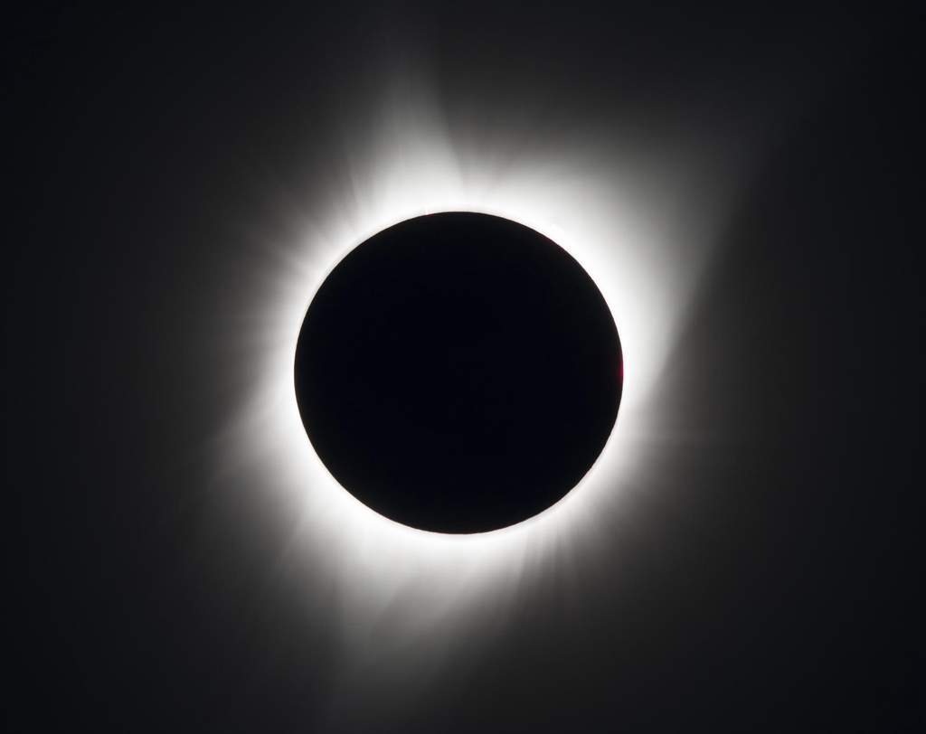

August 21, 2017, above Madras, Oregon, two hours from here. For two minutes the Moon covered the Sun exactly, the sky went dark at midday, and the Sun's outer atmosphere, the **corona**, came out like a white flame.

But wait. Last lesson the Sun, the Earth and the Moon lined up twice a month, at New and at Full. So why doesn't this happen every month? And at Full Moon, with the Earth in the middle, why isn't the Moon always in Earth's shadow?

Today: where shadows come from, and why eclipses are rare.

2017 total solar eclipse, Madras, Oregon. NASA/Aubrey Gemignani

## 1 · Eclipses at a glance

🌑

2 kinds

Lunar and solar

lunar at Full Moon, solar at New Moon

📐

Tilt of the Moon's orbit

to the ecliptic, so the shadows usually miss

🔁

≈ 6 months

Eclipse season

a lunar and a solar eclipse of some type each time

🌍

18 mo · 350 yr

Total solar eclipses

somewhere on Earth every 18 months; at any one spot about once every 350 years

## 2 · Eclipses

We will talk about eclipses, but first we need **trig**: to find side lengths and angles we cannot measure directly. Click a tile; they go in order.

[figure not shown]

1

Trig: SOH CAH TOA

sides and angles of right triangles

[figure not shown]

2

Umbra and penumbra

where a shadow's parts come from

[figure not shown]

3

Lunar eclipse

at Full Moon, and why it turns red

[figure not shown]

4

Solar eclipse

at New Moon: total, annular, partial

[figure not shown]

5

Why not every month?

the 5° tilt and eclipse seasons

[figure not shown]

6

Lucky us

400× bigger, 400× farther

← scroll the tiles →

[figure not shown]

### Trig: SOH CAH TOA

**Trigonometry** lets you use any three of the labelled values of a right triangle (two sides and an angle, or three sides) to solve for the fourth. Name the sides from the angle $\theta$ you are using: the **hypotenuse** is the long side across from the right angle, the **opposite** side is across from $\theta$, and the **adjacent** side touches $\theta$.

**SOH CAH TOA** [3 EQs] $$\sin(\theta) = \frac{\text{opp}}{\text{hyp}} \qquad \cos(\theta) = \frac{\text{adj}}{\text{hyp}} \qquad \tan(\theta) = \frac{\text{opp}}{\text{adj}}$$ To find an **angle**, use the inverse: $\theta = \sin^{-1}\!\left(\frac{\text{opp}}{\text{hyp}}\right)$, and the same for $\cos^{-1}$ and $\tan^{-1}$. Put your calculator in **degrees**.

Drag the corner: watch the three ratios

[interactive chart not shown]

Pick the unknown:

Ex. 1 to 6 · Trig

**Ex. 1.** A right triangle has hypotenuse 10 and angle $30^\circ$. Solve for the opposite side $y$ and the adjacent side $x$.

**Reveal**

$y$: $\sin(30^\circ) = \dfrac{y}{10}$, so $y = 10\sin 30^\circ = \boxed{5}$  
$x$: $\cos(30^\circ) = \dfrac{x}{10}$, so $x = 10\cos 30^\circ = 10\cdot\dfrac{\sqrt3}{2} = \boxed{5\sqrt3 \approx 8.66}$

**Ex. 2.** Hypotenuse 4, angle $40^\circ$. Solve for $y$ (opposite) and $x$ (adjacent).

**Reveal**

$y = 4\sin 40^\circ = \boxed{2.57}$ and $x = 4\cos 40^\circ = \boxed{3.06}$

**Ex. 3.** Angle $25^\circ$, adjacent side 6. Solve for the opposite side $x$.

**Reveal**

Opposite and adjacent: TOA. $\tan(25^\circ) = \dfrac{x}{6}$, so $x = 6\tan 25^\circ = \boxed{2.80}$

**Ex. 4.** Angle $35^\circ$, opposite side 5. Solve for the adjacent side $x$.

**Reveal**

$$\begin{aligned} \tan(35^\circ) &= \frac{5}{x} \\ 0.7 &= \frac{5}{x} \\ x\,(0.7) &= 5 \quad\Rightarrow\quad x = \boxed{7.14} \end{aligned}$$

**Ex. 5.** Opposite 3, adjacent 4. Find the angle $x$.

**Reveal**

$\tan(x) = \dfrac34$, so $x = \tan^{-1}\!\left(\dfrac34\right) = \boxed{36.9^\circ}$

**Ex. 6.** Hypotenuse 5, adjacent 3. Find the angle $\theta$.

**Reveal**

$\cos(\theta) = \dfrac35 = 0.6$, so $\theta = \cos^{-1}(0.6) = \boxed{53.1^\circ}$

Your turn

| Hypotenuse 8, angle $35^\circ$. Opposite side? |  |
| --- | --- |
| Opposite 2, hypotenuse 7. Angle? | ° |

Trig comes back in Unit 3, when the angles get tiny and we use it to measure the distances to stars (parallax).

### Umbra and penumbra

**Demo:** hold a rubber ball in front of a light and look at its shadow on the whiteboard. The middle is dark and sharp; around it is a fuzzy grey ring. A light bulb (or the Sun) is not a point. It is a disk, so a shadow has two parts:

- **Umbra**, the dark middle: the *whole* Sun is blocked. Find its edges with lines from the **same side** of the Sun and the ball (top to top, bottom to bottom). They close into a cone.
- **Penumbra**, the grey ring: *part* of the Sun is blocked. Its edges are lines from **opposite sides** (top of the Sun to the bottom of the ball). They spread out.

Past the tip of the umbra cone is the **antumbra**: the ball looks smaller than the Sun there, and covers only its middle.

Predict first: drag yourself to where the Sun is completely covered

[interactive chart not shown]

Moon closeMoon far

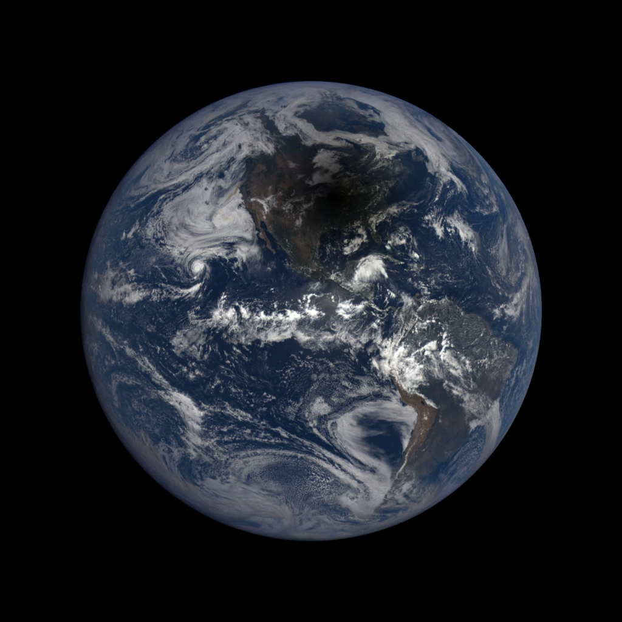

**The Moon's shadow on Earth**, August 21, 2017, from a million miles away. The big grey smudge over North America is the penumbra (a partial eclipse); the dark core at its centre is the umbra, where it was total. NASA EPIC team (DSCOVR)

### Lunar eclipse

A **lunar eclipse** happens at **Full Moon**, when the Moon passes through the **Earth's shadow**. Earth's shadow is big, much bigger than the Moon, so when they line up the umbra covers the whole Full Moon. Everyone on the night side of Earth sees it, and it lasts for hours.

The Moon does not go black. It turns **red**. Sunlight that skims through Earth's atmosphere is **refracted** (bent) into the shadow, and the air scatters the blue out of it first. That red light is every sunrise and sunset on Earth, shining on the Moon at once.

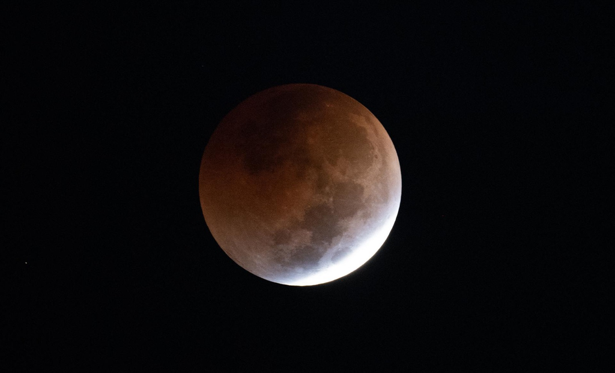

**Totality**, November 8, 2022. The Moon sits inside Earth's umbra and glows red. NASA/Joel Kowsky

[figure not shown]

**The same night, ten exposures**: the Moon slides into Earth's shadow and darkens to red as it sets. NASA/Joel Kowsky

Why red: the atmosphere bends sunlight into the shadow

[interactive chart not shown]

Measure: from a lunar eclipse to a solar one

Eclipses come in pairs: a lunar eclipse at one Full Moon, and a solar eclipse at the New Moon before or after it. How many days apart are they?

days

#### 🔭 Lunar eclipses you can see from Portland (computed)

| **Aug 17, 2027**, about midnight | penumbral: the Moon dims only slightly. Hard to notice. |
| --- | --- |
| **Jan 11, 2028**, about 8:15 pm | partial: Earth's umbra takes a bite out of the Moon, high in the evening sky. Mark your calendar. |

### Solar eclipse

A **solar eclipse** happens at **New Moon**, when the **Moon's shadow** falls on the Earth. The Moon's shadow is small: only a spot of umbra, about 100 to 200 km wide, sweeps across the Earth. That is why a total solar eclipse is so rare in any one place. Where you stand in the shadow decides what you see:

**Total**  
You are in the **umbra**. The whole Sun is covered and the corona comes out. Just before and after: **Baily's beads** (sunlight through valleys on the Moon's edge) and the **diamond ring**.

**Annular**  
You are in the **antumbra**. The Moon is a bit farther away and looks smaller than the Sun: a "ring of fire".

**Partial**  
You are in the **penumbra**. The Moon covers part of the Sun. Most people see this kind.

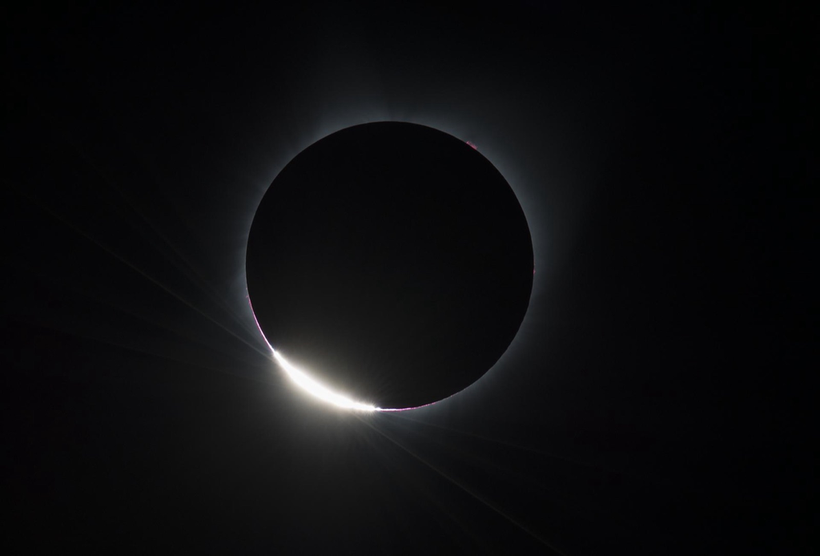

**The diamond ring**, the last flash of the Sun before totality, Madras, 2017. NASA/Aubrey Gemignani

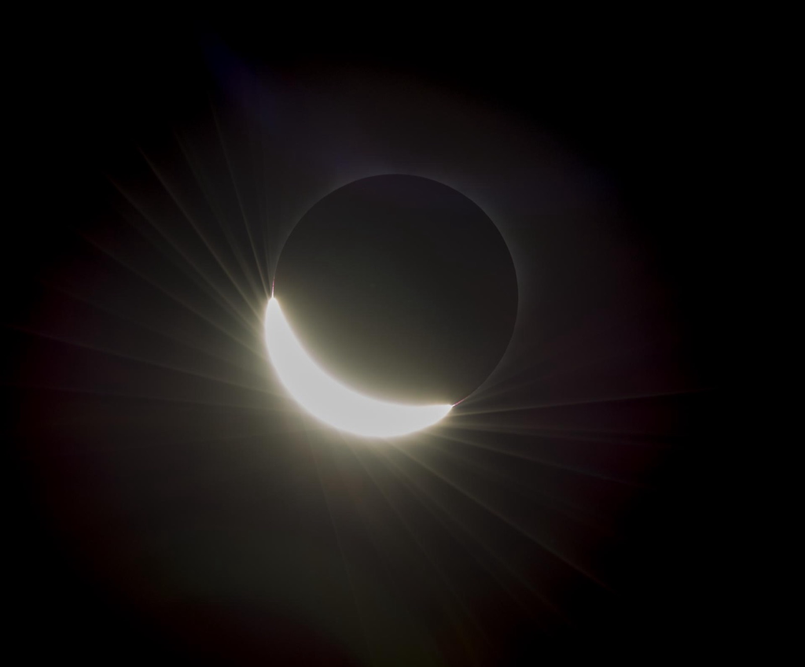

**The last glimmer**: the crescent breaks up into Baily's beads as the Moon's mountains cover it. NASA/Aubrey Gemignani

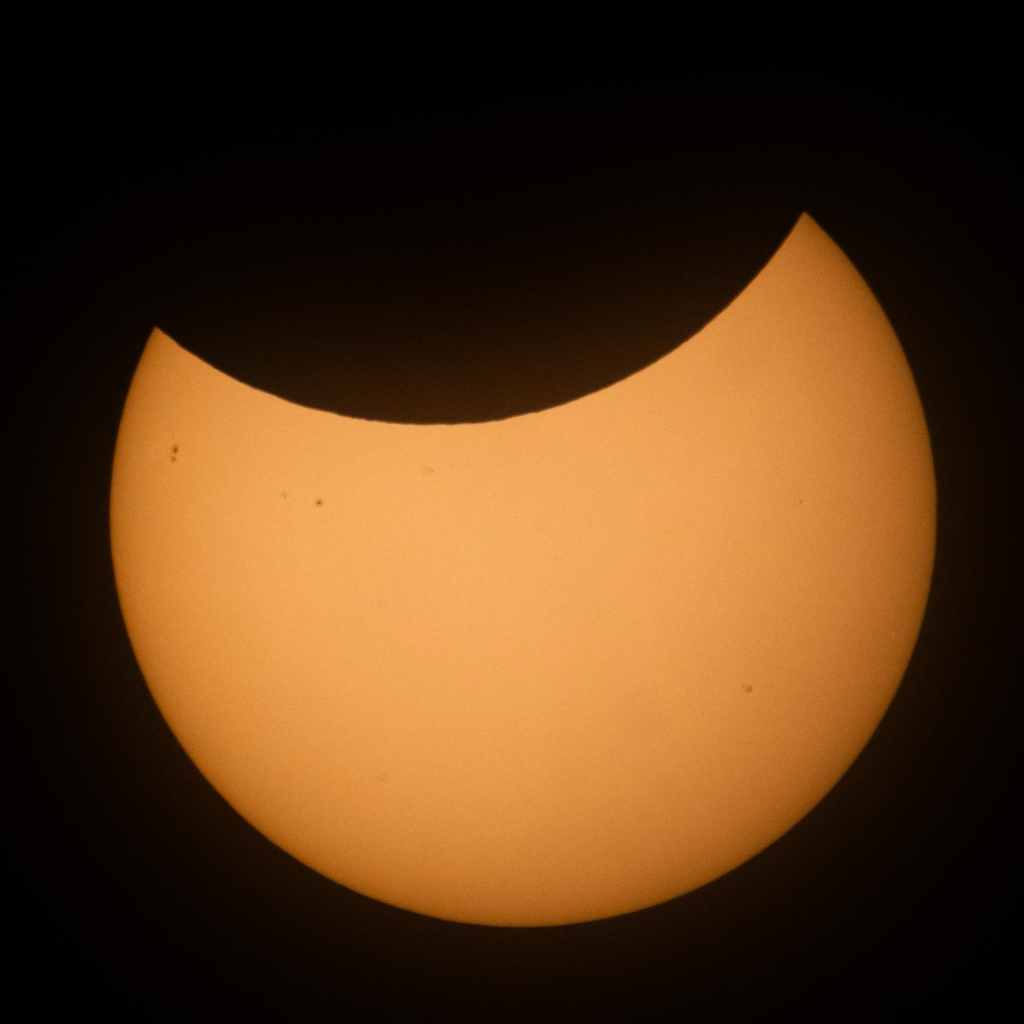

**Partial**, August 12, 2026, from Maine. Totality that day crossed Iceland and Spain. NASA/Joel Kowsky

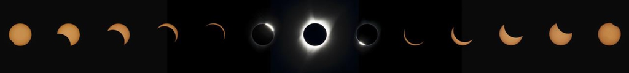

**The whole show in thirteen frames**, Madras High School, 2017: partial, total, partial. NASA/Aubrey Gemignani

**▶ Watch: what it's like to watch a total solar eclipse (Veritasium, filmed in Madras, Oregon)**

[interactive chart not shown]

If it will not play here, [open it on YouTube](https://www.youtube.com/watch?v=G10m2ZZRH4U).

Measure: the Moon and the Sun look the same size

| $\dfrac{d_\odot}{d_{\rm moon}} = \dfrac{1.5\times10^{11}\ \text{m}}{3.84\times10^{8}\ \text{m}}$ (how many times farther is the Sun?) |  |
| --- | --- |
| $\dfrac{R_\odot}{R_{\rm moon}} = \dfrac{6.96\times10^{8}\ \text{m}}{1.74\times10^{6}\ \text{m}}$ (how many times bigger is the Sun?) |  |

#### 🔭 Coming up (computed)

| **Aug 2, 2027** | total, across North Africa and Egypt: over six minutes long at its best. |
| --- | --- |
| **Jan 14, 2029**, at sunrise | partial from Portland: about 68% of the Sun covered, very low in the southeast. Use eclipse glasses. |

Never look at the Sun without certified eclipse glasses, except during the minutes of totality.

### Why don't eclipses happen every time?

The Earth goes around the Sun in a flat plane, the **ecliptic**. The Moon's orbit is tipped by $i = 5^\circ$ to it. Most New and Full Moons the Moon passes a little above or below the line to the Sun, and the shadows miss.

Measure: how far can the Moon miss by?

At its highest the Moon is $5^\circ$ above the ecliptic, 384,000 km from Earth. Use SOH: $\sin(5^\circ) = \dfrac{x}{384{,}000\ \text{km}}$.

| Height above the ecliptic, $x$ | km |
| --- | --- |
| In Earth radii ($R_\oplus = 6{,}370$ km) | $R_\oplus$ |

So the Moon's shadow can pass more than five Earths above or below us. An eclipse needs the Moon to be **crossing the ecliptic** right at New or Full. That happens only when the Sun lines up with the places the Moon's orbit crosses the ecliptic, which comes around about **every 6 months**: an **eclipse season**, with a lunar and a solar eclipse of some type.

A year from above: when do the New and Full Moons hit?

[interactive chart not shown]

rate

month

**For a total solar eclipse**, three things at once:

1. **New phase**.
2. The Moon **crossing the ecliptic**.
3. The Moon **close enough** that its umbra reaches the Earth (otherwise it is annular).

### Lucky us

We are lucky to have total eclipses at all. The Sun is about **400 times bigger** than the Moon, and about **400 times farther away**, so in our sky they are almost exactly the same size. No other planet in the solar system gets eclipses this perfect.

It will not last. The Moon **moves away from us about 3.8 cm every year** (measured by bouncing lasers off mirrors the Apollo astronauts left there). In about **600 million years** it will look too small to cover the Sun, and there will be **no more total eclipses**: only annular ones.

Slide through time: the Moon against the Sun

[interactive chart not shown]

now+1 billion years

Measure: how much farther in 600 million years?

$d = (3.8\ \text{cm/yr})(6\times10^{8}\ \text{yr})$. Give your answer in km (1 km $= 10^{5}$ cm).

km

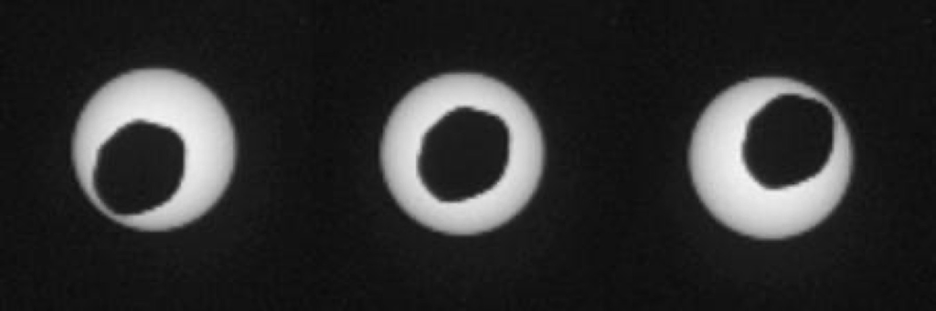

**An eclipse on Mars.** Curiosity watched Phobos cross the Sun in 2013. Phobos is far too small to cover it: Mars only gets annular eclipses. NASA/JPL-Caltech/MSSS/Texas A&M Univ.

## 3 · Name that eclipse

Swipe through the pictures, or use the arrows. Decide **what kind of eclipse** each one is, then tap the picture to reveal.

[figure not shown]

Keyboard: ← → to move, space to reveal (click the picture first). On a phone, swipe left or right.

**Sources and further reading**

Want to dig deeper? Each title links straight to the original.

**Eclipses**

- [Eclipses](https://science.nasa.gov/eclipses/) (NASA): solar and lunar eclipses, how to watch them safely, and what scientists learn from them.
- [Types of solar eclipses](https://science.nasa.gov/eclipses/types/) (NASA): total, annular, partial and hybrid, with pictures.
- [Eclipses and the Moon](https://science.nasa.gov/moon/eclipses/) (NASA): lunar eclipses, and why the Moon turns red.
- [Future eclipses](https://science.nasa.gov/eclipses/future-eclipses/) (NASA): what is coming and where to see it.
- [NASA Eclipse Web Site](https://eclipse.gsfc.nasa.gov/eclipse.html) (Fred Espenak, NASA GSFC): maps and tables for every eclipse for thousands of years.
- [Eclipses](https://minutelabs.io/eclipses/) (MinuteLabs): an interactive that lets you move the Sun, Earth and Moon and make your own eclipse.

**The 2017 eclipse and the video**

- [What it's like to watch a total solar eclipse](https://www.youtube.com/watch?v=G10m2ZZRH4U) (Veritasium, YouTube): filmed in Madras, Oregon.
- [EPIC: Earth from a million miles](https://epic.gsfc.nasa.gov/) (NASA DSCOVR): the camera that photographed the Moon's shadow on North America.
- [2017 total solar eclipse map](https://svs.gsfc.nasa.gov/4518) (NASA Scientific Visualization Studio): the path of the umbra across the United States.

**Lucky us**

- [Lunar laser ranging](https://en.wikipedia.org/wiki/Lunar_Laser_Ranging_experiments) (Wikipedia): the mirrors left by Apollo, and how they measure the Moon moving away 3.8 cm a year.
- [Moon facts](https://science.nasa.gov/moon/facts/) (NASA): the Moon's size and distance.

Upcoming eclipses were computed for Portland with Astronomy Engine (github.com/cosinekitty/astronomy).

**Image credits**

From the NASA Image and Video Library. 2017 Total Solar Eclipse, Madras, Oregon (NHQ201708210100, NHQ201708210102, NHQ201708210103, NHQ201708210116), NASA/Aubrey Gemignani. Total Lunar Eclipse, November 8, 2022 (NHQ202211080005, NHQ202211080009), NASA/Joel Kowsky. 2026 Partial Solar Eclipse, Hodgdon, Maine (NHQ202608120103), NASA/Joel Kowsky. NASA's EPIC View of 2017 Eclipse Across America, NASA (DSCOVR EPIC). Annular Eclipse of the Sun by Phobos, as Seen by Curiosity (PIA17356), NASA/JPL-Caltech/Malin Space Science Systems/Texas A&M Univ. The ring-of-fire picture and all other figures are drawn on this page.